# Determinants de l’utilisation des méthodes contraceptives modernes chez les femmes en âge de procréer (15 à 49 ans) en République Démocratique du Congo (RDC)

Cedric Mwanga

2025-08-26

# 1. Introduction

## Contexte de la RDC

La République Démocratique du Congo (RDC), pays d’Afrique centrale, s’étend sur plus de 2,3 millions de km² et compte une population de plus de 100 millions d’habitants en 2025. Sa population est très jeune, avec plus de la moitié âgée de moins de 18 ans, ce qui exerce une forte pression sur les systèmes de santé, d’éducation et d’emploi.

Dans le domaine de la santé reproductive, la planification familiale représente un enjeu crucial.

## Objectif principal

L’objetif principal de l’etude est d’analyser les déterminants sociodémographiques et économiques associés à l’utilisation des méthodes contraceptives modernes chez les femmes âgées de 15 à 49 ans en RDC, à partir des données de l’Enquête Démographique et de Santé (EDS).

## Objectif spécifiques

De manière plus détaillée, la recherche vise à :

- Évaluer l’influence de l’âge des femmes sur l’utilisation des méthodes contraceptives modernes.
- Examiner l’effet du niveau d’éducation sur l’adoption des méthodes modernes de contraception.
- Analyser l’impact du statut matrimonial sur l’utilisation de la contraception moderne.
- Comparer l’utilisation des méthodes modernes selon le lieu de résidence (urbain/rural).
- Étudier l’association entre le quintile de richesse et l’usage des contraceptifs moderne.

# 2. Description des données démographiques de base

En RDC, selon les données de l’EDS, le nombre total des femmes de 15 à 49 ans enquetées est de 18 827 dont 63.7 % vivent en milieu rural et 36.3 % en milieu urbain.

Le pourcentage de femmes qui utilisent une methode de contraception moderne est de 6.9 %.

Le tableau 1 presente la situation global de toutes ces femmes, reparties comme suit :  
a. Concernant le millieu de residence : 36.3% des femmes vivent en millieu urbain vs 63.7% en millieu rural;  
b. Pour ce qui est du niveau d’education : 17.8% ont aucun niveau, 38.9% ont un niveau d’education primaire, 40.3% ont un niveau d’education secondaire et 3.0% ont un niveau d’education supérieur  
c. S’agissant de la repartition des richesses : 23.2% sont plus pauvre,19.9% sont pauvres, 19.4% ont une richesse moyenne, 18.0% sont riches, et 19.5% sont plus riches  
d. Pour ce qui est de l’utilisation de la contraception moderne : seules 6.9% des femmes utilisent la contraception moderne , tandis que 93.1% ne l’utilisent pas.

Tableau 1 : Les indicateurs démographiques et contraceptifs

| Section | Indicateur | Valeur |
| --- | --- | --- |
| Apercu | Nombre total de femmes | 18 827 |
|  | Age moyen | 28 |
|  | Age median | 27 |
| Éducation | no education | 3 357 (17.8%) |
|  | primary | 7 320 (38.9%) |
|  | secondary | 7 589 (40.3%) |
|  | higher | 561 (3.0%) |
| Statut matrimonial | never in union | 4 545 (24.1%) |
|  | currently in union/living with a man | 12 448 (66.1%) |
|  | formerly in union/living with a man | 1 834 (9.7%) |
| Résidence | urban | 6 827 (36.3%) |
|  | rural | 12 000 (63.7%) |
| Richesse | poorest | 4 366 (23.2%) |
|  | poorer | 3 740 (19.9%) |
|  | middle | 3 655 (19.4%) |
|  | richer | 3 390 (18.0%) |
|  | richest | 3 676 (19.5%) |
| Contraception moderne | N’utilise pas de méthode moderne | 17 526 (93.1%) |
|  | Utilise une méthode moderne | 1 301 (6.9%) |

# 3.Age des femmes et utilisation des méthodes contraceptives modernes.

En RDC, l’âge joue un rôle, avec une utilisation des méthodes modernes légèrement plus élevée chez les 20–35 ans. Mais l’effet n’est pas très marqué : globalement, dans tous les groupes d’âge, la majorité des femmes n’utilisent pas de méthodes modernes. Cela reflète une faible couverture contraceptive moderne en RDC, quel que soit l’âge.

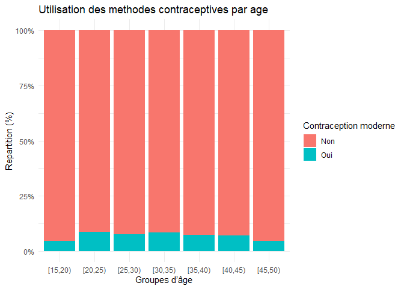

# 4.Niveau d’éducation et l’adoption des méthodes modernes de contraception.

Plus le niveau d’éducation est élevé, plus les femmes adoptent les méthodes modernes de contraception.

Cependant, même dans les catégories les plus instruites, la majorité reste non utilisatrice, ce qui souligne une faible prévalence générale et peut indiquer la présence d’autres obstacles (culturels, économiques, disponibilité des services).

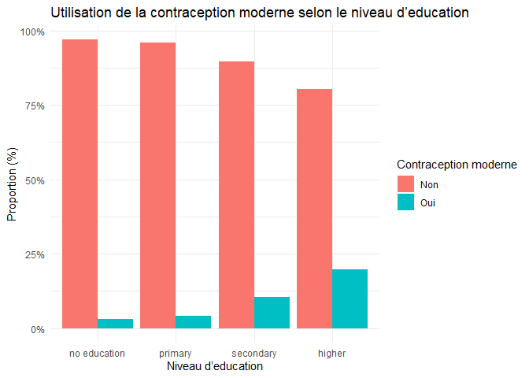

# 5. Impact du statut matrimonial sur l’utilisation de la contraception moderne.

L’utilisation de la contraception moderne reste globalement faible dans tous les statuts matrimoniaux.

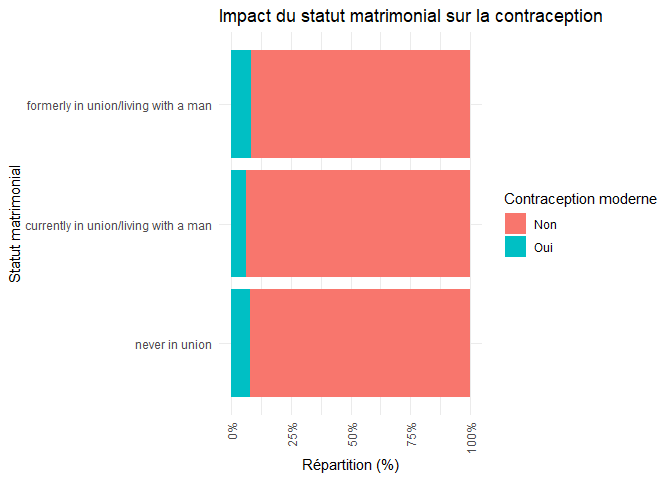

# 6. Utilisation des méthodes modernes selon le lieu de résidence (urbain/rural).

Les femmes vivant en zone urbaine ont significativement plus recours à la contraception moderne que celles vivant en zone rurale.

Toutefois, la couverture reste faible dans les deux milieux, indiquant un besoin de renforcement des programmes d’accès et de sensibilisation en particulier dans les zones rurales.

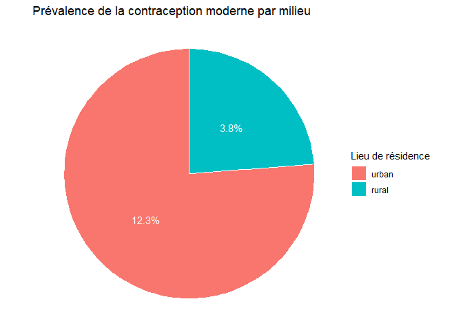

# 7. Association entre le quintile de richesse et l’usage des contraceptifs moderne.

L’adoption de la contraception moderne augmente avec le niveau de richesse.

Les femmes issues des ménages les plus riches sont environ 4 à 5 fois plus susceptibles d’utiliser une méthode moderne que celles issues des ménages les plus pauvres.

Cela suggère que la capacité financière et l’accès aux services constituent des déterminants majeurs de l’utilisation.

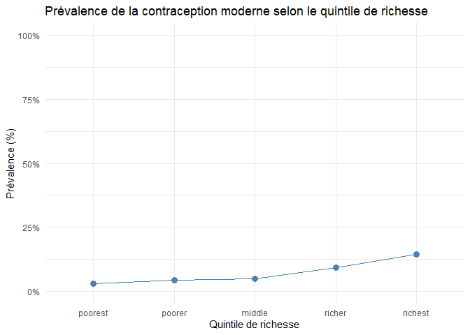

# 8. Conclusion